# Обучение с учителем, качество модели

**Цель проекта:**

Разработать решение, которое будет предлагать индивидуальные предложения постоянным клиентам с целью повышения их покупательской активности.

**Описание данных:**

`market_file.csv`

Таблица, которая содержит данные о поведении покупателя на сайте, о коммуникациях с покупателем и его продуктовом поведении.

- `id` — номер покупателя в корпоративной базе данных.
- `Покупательская активность` — рассчитанный класс покупательской активности (целевой признак): «снизилась» или «прежний уровень».
- `Тип сервиса` — уровень сервиса, например «премиум» и «стандарт».
- `Разрешить сообщать` — информация о том, можно ли присылать покупателю дополнительные предложения о товаре. Согласие на это даёт покупатель.
- `Маркет_актив_6_мес` — среднемесячное значение маркетинговых коммуникаций компании, которое приходилось на покупателя за последние 6 месяцев. Это значение показывает, какое число рассылок, звонков, показов рекламы и прочего приходилось на клиента.
- `Маркет_актив_тек_мес` — количество маркетинговых коммуникаций в текущем месяце.
- `Длительность` — значение, которое показывает, сколько дней прошло с момента регистрации покупателя на сайте.
- `Акционные_покупки` — среднемесячная доля покупок по акции от общего числа покупок за последние 6 месяцев.
- `Популярная_категория` — самая популярная категория товаров у покупателя за последние 6 месяцев.
- `Средний_просмотр_категорий_за_визит` — показывает, сколько в среднем категорий покупатель просмотрел за визит в течение последнего месяца.
- `Неоплаченные_продукты_штук_квартал` — общее число неоплаченных товаров в корзине за последние 3 месяца.
- `Ошибка_сервиса` — число сбоев, которые коснулись покупателя во время посещения сайта.
- `Страниц_за_визит` — среднее количество страниц, которые просмотрел покупатель за один визит на сайт за последние 3 месяца.

`market_money.csv`

Таблица с данными о выручке, которую получает магазин с покупателя, то есть сколько покупатель всего потратил за период взаимодействия с сайтом.

- `id` — номер покупателя в корпоративной базе данных.
- `Период` — название периода, во время которого зафиксирована выручка. Например, `'текущий_месяц'` или `'предыдущий_месяц'`.
- `Выручка` — сумма выручки за период.

`market_time.csv`

Таблица с данными о времени (в минутах), которое покупатель провёл на сайте в течение периода.

- `id` — номер покупателя в корпоративной базе данных.
- `Период` — название периода, во время которого зафиксировано общее время.
- `минут` — значение времени, проведённого на сайте, в минутах.

`money.csv`

Таблица с данными о среднемесячной прибыли покупателя за последние 3 месяца: какую прибыль получает магазин от продаж каждому покупателю.

- `id` — номер покупателя в корпоративной базе данных.
- `Прибыль` — значение прибыли.

**План проекта:**

1. Загрузка данных
2. Предобработка данных
3. Исследовательский анализ данных
4. Объединение таблиц
5. Корреляционный анализ
6. Использование пайплайнов
7. Анализ важности признаков
8. Сегментация покупателей
9. Общий вывод

## Загрузка данных

```python
# импорт бибилеотек

!pip install shap -q
!pip install scikit-learn==1.1.3 -q
import shap
import pandas as pd
import numpy as np
from scipy import stats as st
from matplotlib import pyplot as plt
import seaborn as sns
import sklearn
from sklearn.model_selection import train_test_split, RandomizedSearchCV, GridSearchCV
from sklearn.pipeline import Pipeline
from sklearn.linear_model import LogisticRegression
from sklearn.preprocessing import StandardScaler, OneHotEncoder, OrdinalEncoder, MinMaxScaler, LabelEncoder
from sklearn.metrics import accuracy_score, recall_score, precision_score, roc_auc_score
from sklearn.compose import ColumnTransformer
from sklearn.neighbors import KNeighborsClassifier
from sklearn.tree import DecisionTreeClassifier
from sklearn.svm import SVC
from sklearn.impute import SimpleImputer
from sklearn.feature_selection import SelectKBest, f_classif
import warnings
warnings.filterwarnings("ignore")

RANDOM_STATE = 42
TEST_SIZE = 0.25
```

```python
# загрузка данных о поведении покупателя на сайте
market = pd.read_csv('/datasets/market_file.csv')
market.info()
market.head()
```

```
<class 'pandas.core.frame.DataFrame'>
RangeIndex: 1300 entries, 0 to 1299
Data columns (total 13 columns):
 #   Column                               Non-Null Count  Dtype
---  ------                               --------------  -----
 0   id                                   1300 non-null   int64
 1   Покупательская активность            1300 non-null   object
 2   Тип сервиса                          1300 non-null   object
 3   Разрешить сообщать                   1300 non-null   object
 4   Маркет_актив_6_мес                   1300 non-null   float64
 5   Маркет_актив_тек_мес                 1300 non-null   int64
 6   Длительность                         1300 non-null   int64
 7   Акционные_покупки                    1300 non-null   float64
 8   Популярная_категория                 1300 non-null   object
 9   Средний_просмотр_категорий_за_визит  1300 non-null   int64
 10  Неоплаченные_продукты_штук_квартал   1300 non-null   int64
 11  Ошибка_сервиса                       1300 non-null   int64
 12  Страниц_за_визит                     1300 non-null   int64
dtypes: float64(2), int64(7), object(4)
memory usage: 132.2+ KB
```

|  | id | Покупательская активность | Тип сервиса | Разрешить сообщать | Маркет_актив_6_мес | Маркет_актив_тек_мес | Длительность | Акционные_покупки | Популярная_категория | Средний_просмотр_категорий_за_визит | Неоплаченные_продукты_штук_квартал | Ошибка_сервиса | Страниц_за_визит |
| --- | --- | --- | --- | --- | --- | --- | --- | --- | --- | --- | --- | --- | --- |
| 0 | 215348 | Снизилась | премиум | да | 3.4 | 5 | 121 | 0.00 | Товары для детей | 6 | 2 | 1 | 5 |
| 1 | 215349 | Снизилась | премиум | да | 4.4 | 4 | 819 | 0.75 | Товары для детей | 4 | 4 | 2 | 5 |
| 2 | 215350 | Снизилась | стандартт | нет | 4.9 | 3 | 539 | 0.14 | Домашний текстиль | 5 | 2 | 1 | 5 |
| 3 | 215351 | Снизилась | стандартт | да | 3.2 | 5 | 896 | 0.99 | Товары для детей | 5 | 0 | 6 | 4 |
| 4 | 215352 | Снизилась | стандартт | нет | 5.1 | 3 | 1064 | 0.94 | Товары для детей | 3 | 2 | 3 | 2 |

```python
# загрузка данных о выручке, которую получает магазин с покупателя
market_money = pd.read_csv('/datasets/market_money.csv')
market_money.info()
market_money.head()
```

```
<class 'pandas.core.frame.DataFrame'>
RangeIndex: 3900 entries, 0 to 3899
Data columns (total 3 columns):
 #   Column   Non-Null Count  Dtype
---  ------   --------------  -----
 0   id       3900 non-null   int64
 1   Период   3900 non-null   object
 2   Выручка  3900 non-null   float64
dtypes: float64(1), int64(1), object(1)
memory usage: 91.5+ KB
```

|  | id | Период | Выручка |
| --- | --- | --- | --- |
| 0 | 215348 | препредыдущий_месяц | 0.0 |
| 1 | 215348 | текущий_месяц | 3293.1 |
| 2 | 215348 | предыдущий_месяц | 0.0 |
| 3 | 215349 | препредыдущий_месяц | 4472.0 |
| 4 | 215349 | текущий_месяц | 4971.6 |

```python
# загрузка данных о времени (в минутах), которое покупатель провёл на сайте в течение периода
market_time = pd.read_csv('/datasets/market_time.csv')
market_time.info()
market_time.head()
```

```
<class 'pandas.core.frame.DataFrame'>
RangeIndex: 2600 entries, 0 to 2599
Data columns (total 3 columns):
 #   Column  Non-Null Count  Dtype
---  ------  --------------  -----
 0   id      2600 non-null   int64
 1   Период  2600 non-null   object
 2   минут   2600 non-null   int64
dtypes: int64(2), object(1)
memory usage: 61.1+ KB
```

|  | id | Период | минут |
| --- | --- | --- | --- |
| 0 | 215348 | текущий_месяц | 14 |
| 1 | 215348 | предыдцщий_месяц | 13 |
| 2 | 215349 | текущий_месяц | 10 |
| 3 | 215349 | предыдцщий_месяц | 12 |
| 4 | 215350 | текущий_месяц | 13 |

```python
# загрузка данных о среднемесячной прибыли покупателя за последние 3 месяца
money = pd.read_csv('/datasets/money.csv', sep=';', decimal=',')
money.info()
money.head()
```

```
<class 'pandas.core.frame.DataFrame'>
RangeIndex: 1300 entries, 0 to 1299
Data columns (total 2 columns):
 #   Column   Non-Null Count  Dtype
---  ------   --------------  -----
 0   id       1300 non-null   int64
 1   Прибыль  1300 non-null   float64
dtypes: float64(1), int64(1)
memory usage: 20.4 KB
```

|  | id | Прибыль |
| --- | --- | --- |
| 0 | 215348 | 0.98 |
| 1 | 215349 | 4.16 |
| 2 | 215350 | 3.13 |
| 3 | 215351 | 4.87 |
| 4 | 215352 | 4.21 |

**Выводы:**

- Данные сооветствуют описанию
- В таблицах нет пропусков
- Типы данных в столбцах соответствующие

## Предобработка данных

### Обработка дубликатов

```python
print(f'Количество дубликатов в market_file.csv: {market.duplicated().sum()}')

print(f'Количество дубликатов в market_money.csv: {market_money.duplicated().sum()}')

print(f'Количество дубликатов в market_time.csv: {market_time.duplicated().sum()}')

print(f'Количество дубликатов в money.csv: {money.duplicated().sum()}')
```

```
Количество дубликатов в market_file.csv: 0
Количество дубликатов в market_money.csv: 0
Количество дубликатов в market_time.csv: 0
Количество дубликатов в money.csv: 0
```

```python
market['Тип сервиса'].unique()
```

```
array(['премиум', 'стандартт', 'стандарт'], dtype=object)
```

```python
# переименование дубликата
market.loc[market['Тип сервиса'] == 'стандартт', 'Тип сервиса'] = 'стандарт'

# проверка уникальных значений
market['Тип сервиса'].unique()
```

```
array(['премиум', 'стандарт'], dtype=object)
```

### изменение названий столбцов

```python
# переименование дубликата
market_time.loc[market_time['Период'] == 'предыдцщий_месяц', 'Период'] = 'предыдущий_месяц'
```

## Исследовательский анализ данных

```python
def viz_num_variable(df, column):
    sns.set(rc={"figure.figsize": (15, 5)})

    fig,axes=plt.subplots(1,2)

    sns.histplot(data=df[column], bins=20, ax=axes[0])
    axes[0].set(ylabel='Частота', xlabel=column)

    sns.boxplot(data=df[column], ax=axes[1])
    axes[1].set(ylabel=column)

    plt.suptitle(f'Распределение {column}')
    plt.show()
```

```python
def viz_cat_variable(df, column):
    sns.countplot(data = df, x=column)

    plt.suptitle(f'Распределение {column}')
    plt.show()
```

### market

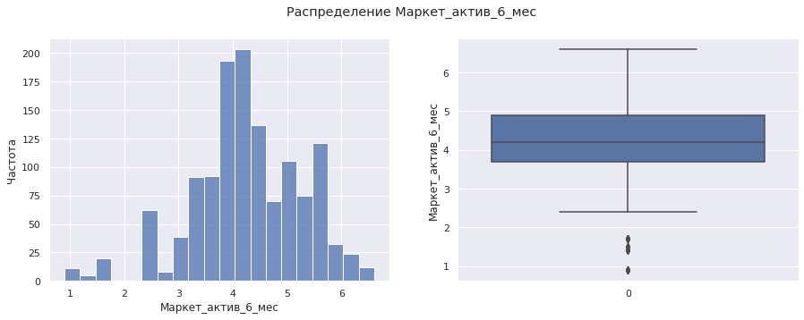

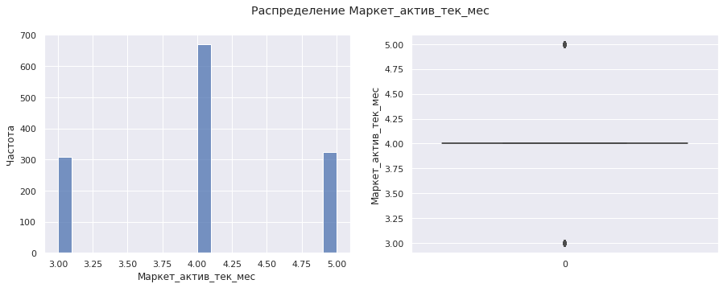

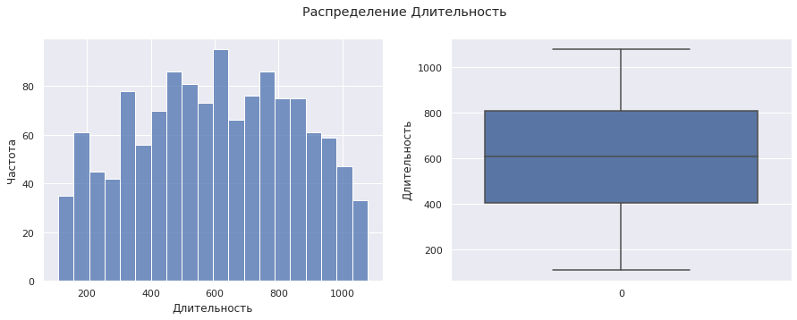

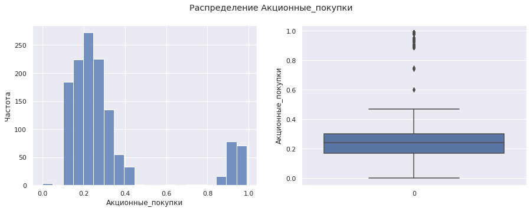

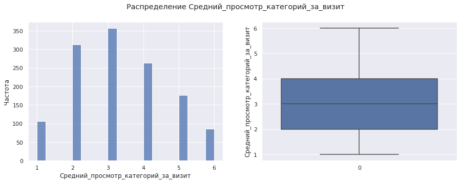

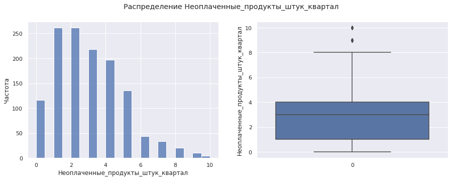

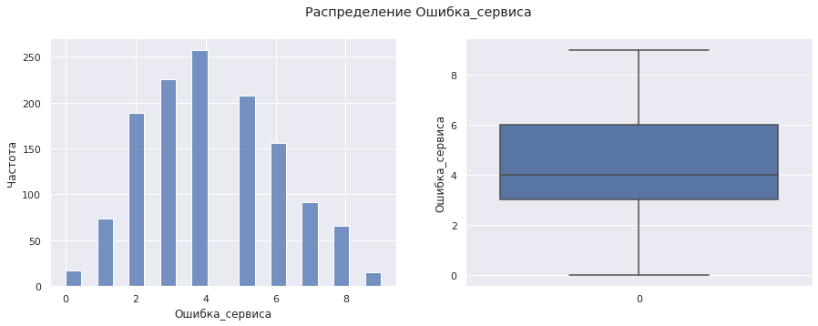

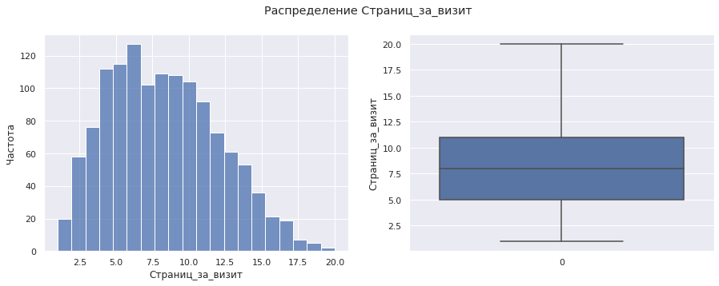

```python
#построение распределений количественных признаков
for name in market.select_dtypes(include=['int64', 'float64']).columns.tolist()[1:]:
    viz_num_variable(market, name)
    market[name].describe()
```

```
Прежний уровень    802
Снизилась          498
Name: Покупательская активность, dtype: int64
```

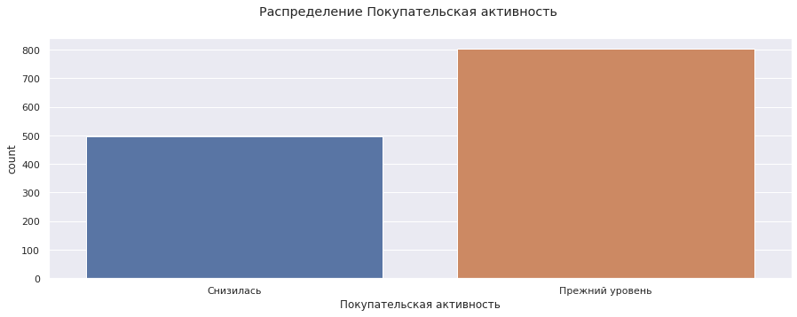

```
стандарт    924
премиум     376
Name: Тип сервиса, dtype: int64
```

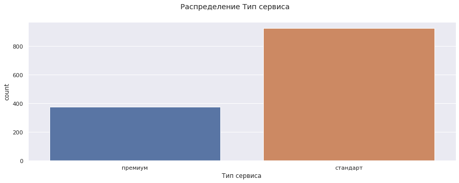

```
да     962
нет    338
Name: Разрешить сообщать, dtype: int64
```

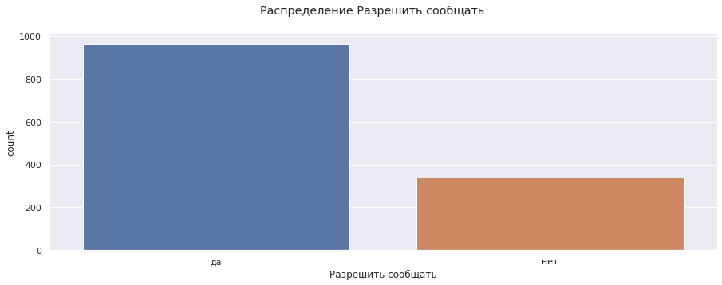

```
Товары для детей                        330
Домашний текстиль                       251
Косметика и аксесуары                   223
Техника для красоты и здоровья          184
Мелкая бытовая техника и электроника    174
Кухонная посуда                         138
Name: Популярная_категория, dtype: int64
```

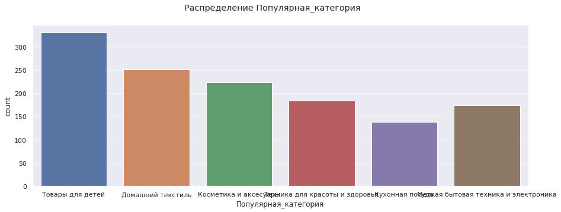

```python
#построение распределений категориальных признаков
for name in market.select_dtypes(include='object').columns.tolist():
    print(market[name].value_counts())
    viz_cat_variable(market, name)
```

### market_money

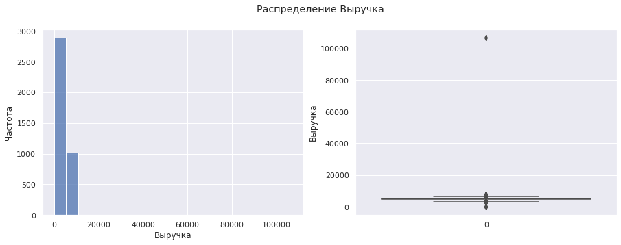

```
count      3900.000000
mean       5025.696051
std        1777.704104
min           0.000000
25%        4590.150000
50%        4957.500000
75%        5363.000000
max      106862.200000
Name: Выручка, dtype: float64
```

```python
#построение распределений количественных признаков
viz_num_variable(market_money, 'Выручка')
market_money['Выручка'].describe()
```

```python
market_money[market_money['Выручка'] > 20000]
```

|  | id | Период | Выручка |
| --- | --- | --- | --- |
| 98 | 215380 | текущий_месяц | 106862.2 |

```python
# удаление аномального значения
market_money = market_money[market_money['id'] != 215380]
market = market[market['id'] != 215380]
market_time = market_time[market_time['id'] != 215380]
money = money[money['id'] != 215380]
```

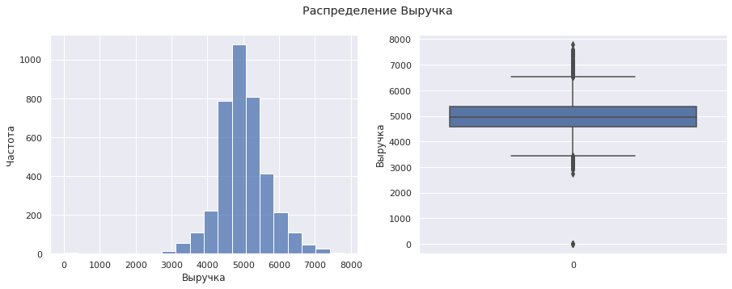

```
count    3897.000000
mean     4999.287760
std       706.970089
min         0.000000
25%      4590.000000
50%      4956.000000
75%      5363.000000
max      7799.400000
Name: Выручка, dtype: float64
```

```python
#построение распределений количественных признаков
viz_num_variable(market_money, 'Выручка')
market_money['Выручка'].describe()
```

### market_time

```
текущий_месяц
```

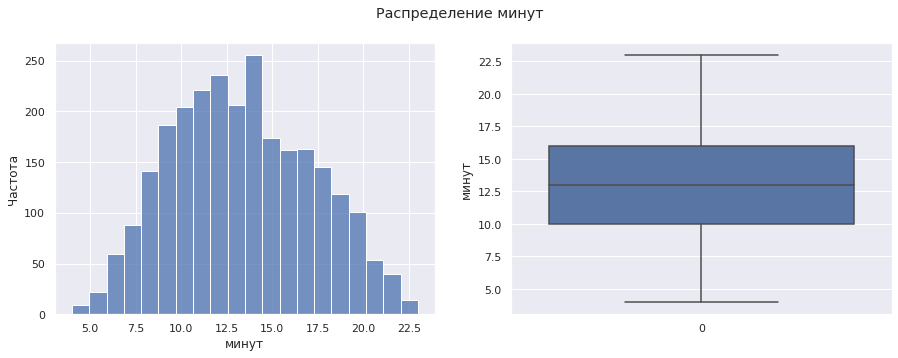

```
предыдущий_месяц
```

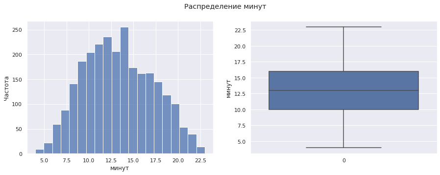

```python
#построение распределений количественных признаков
for period in market_time['Период'].unique().tolist():
    print(period)
    #viz_num_variable(market_time[market_time['Период'] == period], 'минут')
    viz_num_variable(market_time, 'минут')
    market_time['минут'].describe()
```

### money

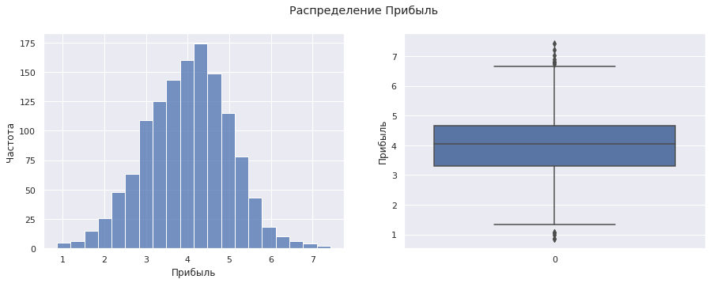

```
count    1299.000000
mean        3.996721
std         1.014107
min         0.860000
25%         3.300000
50%         4.050000
75%         4.670000
max         7.430000
Name: Прибыль, dtype: float64
```

```python
#построение распределений количественных признаков
viz_num_variable(money, 'Прибыль')
money['Прибыль'].describe()
```

### Выбор покупателей, активных в последние 3 месяца

```python
# выбор пользователей, не принесших выручку в течение последних 3 месяцов
market_money.query('Выручка == 0')
```

|  | id | Период | Выручка |
| --- | --- | --- | --- |
| 0 | 215348 | препредыдущий_месяц | 0.0 |
| 2 | 215348 | предыдущий_месяц | 0.0 |
| 28 | 215357 | препредыдущий_месяц | 0.0 |
| 29 | 215357 | предыдущий_месяц | 0.0 |
| 34 | 215359 | предыдущий_месяц | 0.0 |
| 35 | 215359 | препредыдущий_месяц | 0.0 |

```python
# удаление пользоватлей с покупательской активностью менее трёх месяцев
market = market.query('id != [215348, 215357, 215359]')
market_money = market_money.query('id != [215348, 215357, 215359]')
market_time = market_time.query('id != [215348, 215357, 215359]')
money = money.query('id != [215348, 215357, 215359]')
```

### Выводы:

market

market_money

- "Выручка" распределен нормально, аномальноем значение удалено;

market_time

- "Минуты" распределен нормально;

money

- "Прибыль" распределен нормально;

Выбраны пользователи, которые были активны в последние месяца

## Объединение таблиц

### Добавление market_money

```python
#добавление новых столбцов из market_money
for name in market_money['Период'].unique().tolist():
    market = market.merge(market_money[market_money['Период'] == name].drop(columns='Период'),
                          on='id',
                          how='left',
                          suffixes=('_препред', '_пред'))
```

### Добавление market_time

```python
#добавление новых столбцов из market_time
for name in market_time['Период'].unique().tolist():
    market = market.merge(market_time[market_time['Период'] == name].drop(columns='Период'),
                          on='id',
                          how='left',
                          suffixes=('_пред', '_тек'))
```

### Выводы:

- Таблицы объеденены по общему признаку;
- Созданы дополнительные колонки для значений за несколько периодов.

## Корреляционный анализ

```python
market.info()
```

```
<class 'pandas.core.frame.DataFrame'>
Int64Index: 1296 entries, 0 to 1295
Data columns (total 18 columns):
 #   Column                               Non-Null Count  Dtype
---  ------                               --------------  -----
 0   id                                   1296 non-null   int64
 1   Покупательская активность            1296 non-null   object
 2   Тип сервиса                          1296 non-null   object
 3   Разрешить сообщать                   1296 non-null   object
 4   Маркет_актив_6_мес                   1296 non-null   float64
 5   Маркет_актив_тек_мес                 1296 non-null   int64
 6   Длительность                         1296 non-null   int64
 7   Акционные_покупки                    1296 non-null   float64
 8   Популярная_категория                 1296 non-null   object
 9   Средний_просмотр_категорий_за_визит  1296 non-null   int64
 10  Неоплаченные_продукты_штук_квартал   1296 non-null   int64
 11  Ошибка_сервиса                       1296 non-null   int64
 12  Страниц_за_визит                     1296 non-null   int64
 13  Выручка_препред                      1296 non-null   float64
 14  Выручка_пред                         1296 non-null   float64
 15  Выручка                              1296 non-null   float64
 16  минут_пред                           1296 non-null   int64
 17  минут_тек                            1296 non-null   int64
dtypes: float64(5), int64(9), object(4)
memory usage: 192.4+ KB
```

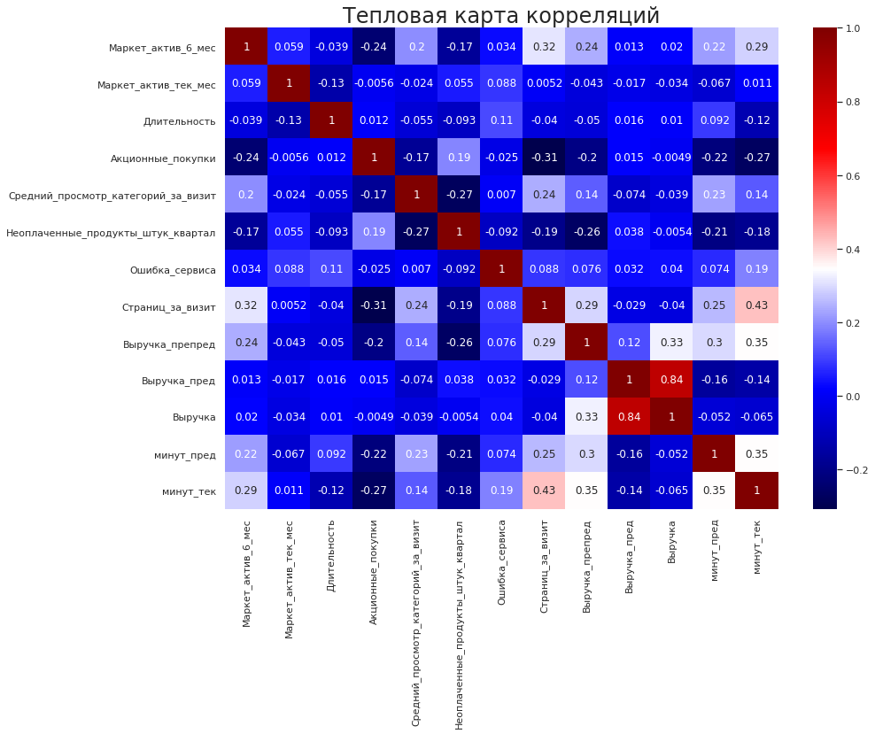

```python
plt.figure(figsize=(14,10))
sns.heatmap(
    market[market.select_dtypes(include=['int64', 'float64']).columns.tolist()[1:]].corr(),
    annot=True,
    cmap='seismic'
)
plt.title('Тепловая карта корреляций', fontsize=24)
plt.show()
```

### Выводы:

- Наблюдается высокая корреляция Выручка_пред и Выручка, но не более 0.9. Мультиколлениарность не наблюдается.

```python
market.info()
```

```
<class 'pandas.core.frame.DataFrame'>
Int64Index: 1296 entries, 0 to 1295
Data columns (total 18 columns):
 #   Column                               Non-Null Count  Dtype
---  ------                               --------------  -----
 0   id                                   1296 non-null   int64
 1   Покупательская активность            1296 non-null   object
 2   Тип сервиса                          1296 non-null   object
 3   Разрешить сообщать                   1296 non-null   object
 4   Маркет_актив_6_мес                   1296 non-null   float64
 5   Маркет_актив_тек_мес                 1296 non-null   int64
 6   Длительность                         1296 non-null   int64
 7   Акционные_покупки                    1296 non-null   float64
 8   Популярная_категория                 1296 non-null   object
 9   Средний_просмотр_категорий_за_визит  1296 non-null   int64
 10  Неоплаченные_продукты_штук_квартал   1296 non-null   int64
 11  Ошибка_сервиса                       1296 non-null   int64
 12  Страниц_за_визит                     1296 non-null   int64
 13  Выручка_препред                      1296 non-null   float64
 14  Выручка_пред                         1296 non-null   float64
 15  Выручка                              1296 non-null   float64
 16  минут_пред                           1296 non-null   int64
 17  минут_тек                            1296 non-null   int64
dtypes: float64(5), int64(9), object(4)
memory usage: 192.4+ KB
```

## Использование пайплайнов

```python
X_train, X_test, y_train, y_test = train_test_split(
    market.drop(['Покупательская активность', 'id'], axis=1),
    market['Покупательская активность'],
    test_size = TEST_SIZE,
    random_state = RANDOM_STATE,
    stratify = market['Покупательская активность'])

#кодирование целевого признака
label_encoder = LabelEncoder()
y_train = label_encoder.fit_transform(y_train)
y_test = label_encoder.transform(y_test)

cat_columns = ['Тип сервиса', 'Разрешить сообщать', 'Популярная_категория']
num_columns = [
    'Маркет_актив_6_мес',
    'Маркет_актив_тек_мес',
    'Длительность',
    'Акционные_покупки',
    'Средний_просмотр_категорий_за_визит',
    'Неоплаченные_продукты_штук_квартал',
    'Ошибка_сервиса',
    'Страниц_за_визит',
    'Выручка_препред',
    'Выручка_пред',
    'Выручка',
    'минут_пред',
    'минут_тек',
              ]

# создаём пайплайн для подготовки признаков
ohe_pipe = Pipeline(
    [('simpleImputer_ohe', SimpleImputer(missing_values=np.nan, strategy='most_frequent')),
     ('ohe', OneHotEncoder(drop='first', handle_unknown='ignore', sparse=False))
    ]
    )

# создаём общий пайплайн для подготовки данных
data_preprocessor = ColumnTransformer(
    [('ohe', ohe_pipe, cat_columns),
     ('num', MinMaxScaler(), num_columns)
    ],
    remainder='passthrough'
)

# создаём итоговый пайплайн: подготовка данных и модель
pipe_final = Pipeline([
    ('preprocessor', data_preprocessor),
    ('models', DecisionTreeClassifier(random_state=RANDOM_STATE))
])

#Параметры для передачи GridSearchCV для поиска оптимальной модели
param_grid = {
    'preprocessor__num': [StandardScaler(), MinMaxScaler(), 'passthrough'],
    'models': [DecisionTreeClassifier(random_state=RANDOM_STATE),
               KNeighborsClassifier(),
               SVC(probability=True, random_state=RANDOM_STATE),
               LogisticRegression(random_state=RANDOM_STATE)]
}

param_distributions = [
    # словарь для модели DecisionTreeClassifier()
    {
        'models': [DecisionTreeClassifier(random_state=RANDOM_STATE)],
        'models__max_depth': range(2, 5),
        'models__max_features': range(2, 5),
        'preprocessor__num': [StandardScaler(), MinMaxScaler(), 'passthrough']
    },

    # словарь для модели KNeighborsClassifier()
    {
        'models': [KNeighborsClassifier()],
        'models__n_neighbors': range(2, 5),
        'preprocessor__num': [StandardScaler(), MinMaxScaler(), 'passthrough']
    },

    # словарь для модели LogisticRegression()
    {
        'models': [LogisticRegression(
            random_state=RANDOM_STATE,
            solver='liblinear',
            penalty='l1'
        )],
        'models__C': range(1, 5),
        'preprocessor__num': [StandardScaler(), MinMaxScaler(), 'passthrough']
    }
]
```

```python
#поиск оптимальной модели без перебора гиперпараметров
grid_0 = GridSearchCV(
    pipe_final,
    param_grid=param_grid,
    cv=5,
    scoring='roc_auc',
    n_jobs=-1
)

#обучение модели на тренировочной выборке
grid_0.fit(X_train, y_train)

#вывод лучшей модели
print('Лучшая модель и её параметры:\n\n', grid_0.best_params_)

#вывод метрики лучшей модели
print('Метрика ROC-AUC для лучшей модели:\n', grid_0.best_score_.round(2))
```

```
Лучшая модель и её параметры:

 {'models': SVC(probability=True, random_state=42), 'preprocessor__num': StandardScaler()}
Метрика ROC-AUC для лучшей модели:
 0.91
```

```python
#поиск оптимальной модели с перебором гиперпараметров
grid_1 = GridSearchCV(
    pipe_final,
    param_grid=param_distributions,
    cv=5,
    scoring='roc_auc',
    n_jobs=-1,
)

#обучение модели на тренировочной выборке
grid_1.fit(X_train, y_train)

print('Метрика ROC-AUC для лучшей модели:\n', grid_1.best_score_.round(2))
print('Лучшая модель и её параметры:\n', grid_1.best_params_)
```

```
Метрика ROC-AUC для лучшей модели:
 0.9
Лучшая модель и её параметры:
 {'models': LogisticRegression(C=1, penalty='l1', random_state=42, solver='liblinear'), 'models__C': 1, 'preprocessor__num': MinMaxScaler()}
```

```python
y_pred = grid_0.predict_proba(X_test)
print(f'Метрика ROC-AUC на тестовой выборке: {roc_auc_score(y_test, y_pred[:, 1]).round(2)}')
```

```
Метрика ROC-AUC на тестовой выборке: 0.91
```

### Выводы:

- Для оценки модели выбрана метрика ROC-AUC, так как она применима к широкому спектру задач, включая бинарную классификацию и менее подвержена влиянию дисбаланса классов, чем многие другие метрики. Значение ROC-AUC легко интерпретируется: чем выше значение, тем лучше модель.
- Найдена наиболее удачная модель и определены ее параметры;
- Лучший результат показала модель SVC.

## Анализ важности признаков

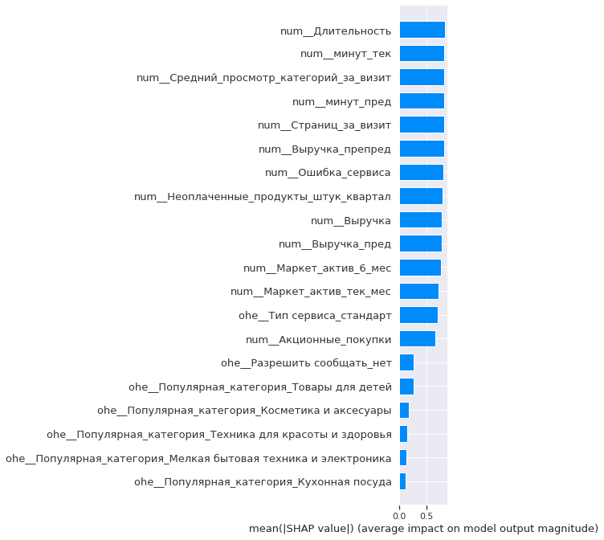

```python
#поиск важных признаков
X_encoded_0 = grid_0.best_estimator_['preprocessor'].fit_transform(X_train)

model_0 = grid_0.best_estimator_['models'].fit(X_encoded_0, y_train)
explainer_0 = shap.PermutationExplainer(model_0, X_encoded_0)


labels_0 = grid_0.best_estimator_[:-1].get_feature_names_out()

shap.summary_plot(X_encoded_0, plot_type='bar', feature_names=labels_0)
```

## Сегментация покупателей

```python
#добавление к данным вероятности отношения к классу 1

X_test['Вероятность'] = y_pred[:, 1]
df = X_test.sort_values(by='Вероятность')
df.head()
```

|  | Тип сервиса | Разрешить сообщать | Маркет_актив_6_мес | Маркет_актив_тек_мес | Длительность | Акционные_покупки | Популярная_категория | Средний_просмотр_категорий_за_визит | Неоплаченные_продукты_штук_квартал | Ошибка_сервиса | Страниц_за_визит | Выручка_препред | Выручка_пред | Выручка | минут_пред | минут_тек | Вероятность |
| --- | --- | --- | --- | --- | --- | --- | --- | --- | --- | --- | --- | --- | --- | --- | --- | --- | --- |
| 485 | премиум | да | 4.9 | 3 | 888 | 0.14 | Техника для красоты и здоровья | 3 | 1 | 6 | 9 | 5268.0 | 4698.0 | 4893.0 | 18 | 15 | 0.016490 |
| 695 | премиум | да | 3.9 | 4 | 572 | 0.14 | Мелкая бытовая техника и электроника | 4 | 2 | 2 | 6 | 5194.0 | 6262.0 | 5696.5 | 18 | 16 | 0.020425 |
| 1113 | стандарт | да | 4.9 | 4 | 739 | 0.17 | Мелкая бытовая техника и электроника | 5 | 1 | 4 | 4 | 5180.0 | 5917.6 | 5505.5 | 15 | 18 | 0.021465 |
| 453 | стандарт | нет | 4.1 | 4 | 808 | 0.15 | Мелкая бытовая техника и электроника | 4 | 2 | 3 | 13 | 4691.0 | 4746.1 | 4126.0 | 16 | 12 | 0.021675 |
| 1060 | стандарт | да | 5.5 | 3 | 847 | 0.11 | Мелкая бытовая техника и электроника | 5 | 1 | 5 | 4 | 5233.0 | 5351.8 | 5227.0 | 16 | 14 | 0.022551 |

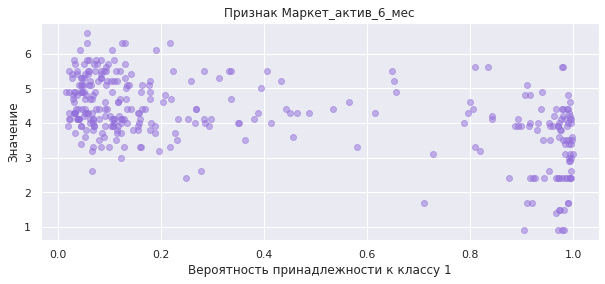

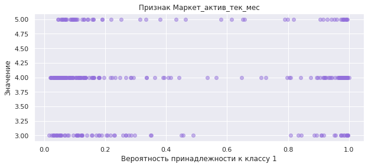

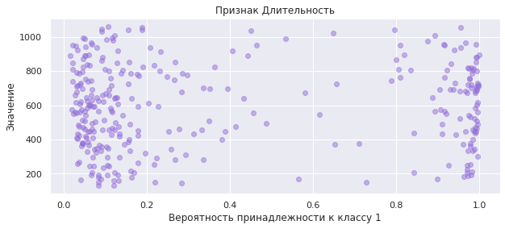

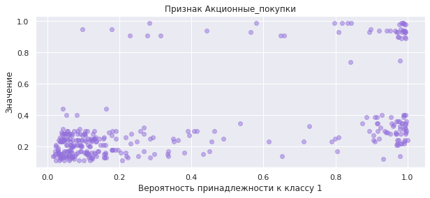

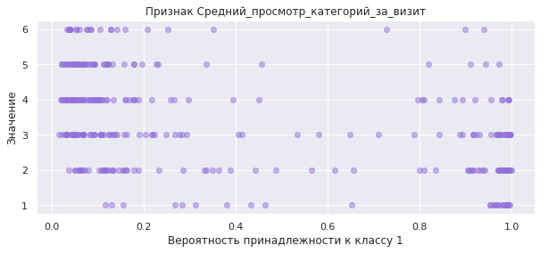

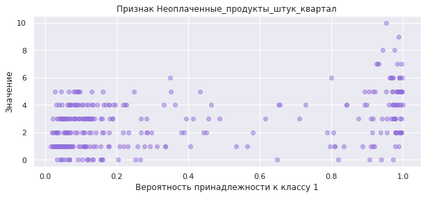

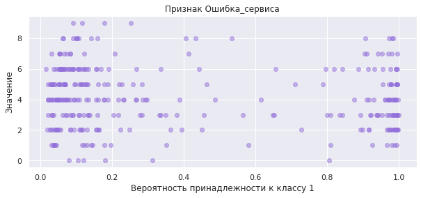

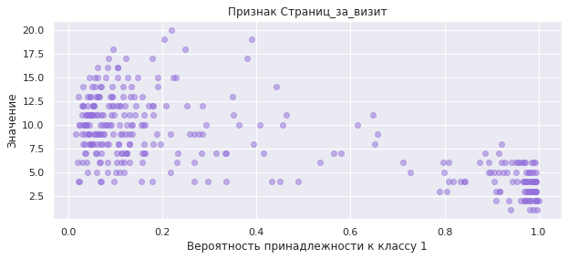

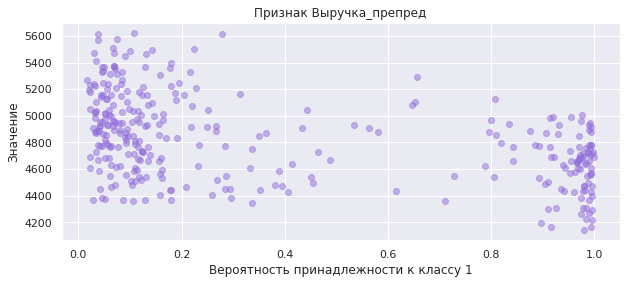

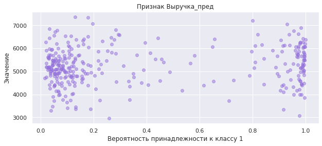

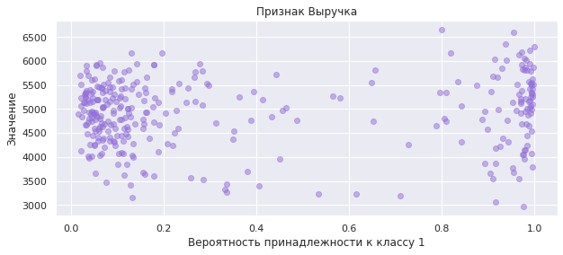

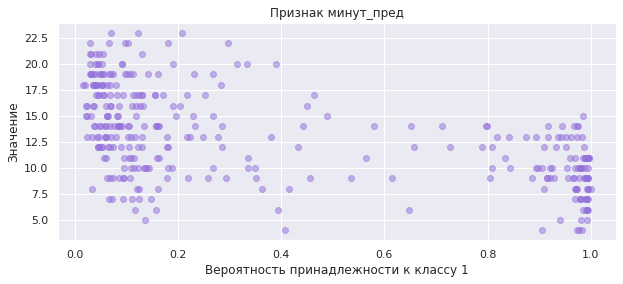

[1 more figures not shown]

```python
for name in num_columns:
    plt.figure(figsize=(10, 4))
    plt.title(f'Признак {name}')
    plt.xlabel('Вероятность принадлежности к классу 1')
    plt.ylabel('Значение')
    plt.scatter(x=df['Вероятность'],
                y=df[name],
                alpha=0.5,
                c='MediumPurple')
```

Исходя из графиков можно выделить пороги значений для разделения покупателей на классы. Покупатели со сниженной активностью имеют значения признака: